# Lab2

Drew Shives

9/18/2021

```r
library("tidyverse")
```

1. Use R to demonstrate that the mean minimizes the sum of the squared deviations from the mean. Accomplish the following steps:
1. Produce a sample of at least 10 or more different numbers

```r
x <- sample(100, 10)
x
```

```
##  [1] 39 73 81 90  3 27 83 10 56 11
```

2. Produce a simulation following the example from the concepts section

```r
scores <- x
sequence <- 1:max(scores)

sum_deviations <- function(scores, sequence) {
  sum_dev <- c()
  for(i in 1:length(sequence)) {
    sum_dev[i] <- sum((scores - sequence[i]) ^ 2)
  }
  return(sum_dev)
}

sum_devs <- sum_deviations(scores, sequence)
sum_devs
```

```
##  [1] 31559 30643 29747 28871 28015 27179 26363 25567 24791 24035 23299 22583
## [13] 21887 21211 20555 19919 19303 18707 18131 17575 17039 16523 16027 15551
## [25] 15095 14659 14243 13847 13471 13115 12779 12463 12167 11891 11635 11399
## [37] 11183 10987 10811 10655 10519 10403 10307 10231 10175 10139 10123 10127
## [49] 10151 10195 10259 10343 10447 10571 10715 10879 11063 11267 11491 11735
## [61] 11999 12283 12587 12911 13255 13619 14003 14407 14831 15275 15739 16223
## [73] 16727 17251 17795 18359 18943 19547 20171 20815 21479 22163 22867 23591
## [85] 24335 25099 25883 26687 27511 28355
```

3. Use your simulation to test a range of numbers smaller and larger than the mean to show that the mean minimizes the sum of the squared deviations from the mean.

```r
below <- 1:(mean(x) - 1)
above <- (mean(x) + 1):100

cat("\n# Below the mean \n")
```

```
##
## # Below the mean
```

```r
sum_deviations(scores, below)
```

```
##  [1] 31559 30643 29747 28871 28015 27179 26363 25567 24791 24035 23299 22583
## [13] 21887 21211 20555 19919 19303 18707 18131 17575 17039 16523 16027 15551
## [25] 15095 14659 14243 13847 13471 13115 12779 12463 12167 11891 11635 11399
## [37] 11183 10987 10811 10655 10519 10403 10307 10231 10175 10139
```

```r
cat("\n# Mean \n")
```

```
##
## # Mean
```

```r
sum_deviations(scores, mean(scores))
```

```
## [1] 10122.1
```

```r
cat("\n# Above the mean \n")
```

```
##
## # Above the mean
```

```r
sum_deviations(scores, above)
```

```
##  [1] 10132.1 10162.1 10212.1 10282.1 10372.1 10482.1 10612.1 10762.1 10932.1
## [10] 11122.1 11332.1 11562.1 11812.1 12082.1 12372.1 12682.1 13012.1 13362.1
## [19] 13732.1 14122.1 14532.1 14962.1 15412.1 15882.1 16372.1 16882.1 17412.1
## [28] 17962.1 18532.1 19122.1 19732.1 20362.1 21012.1 21682.1 22372.1 23082.1
## [37] 23812.1 24562.1 25332.1 26122.1 26932.1 27762.1 28612.1 29482.1 30372.1
## [46] 31282.1 32212.1 33162.1 34132.1 35122.1 36132.1 37162.1
```

4. Plot your results.

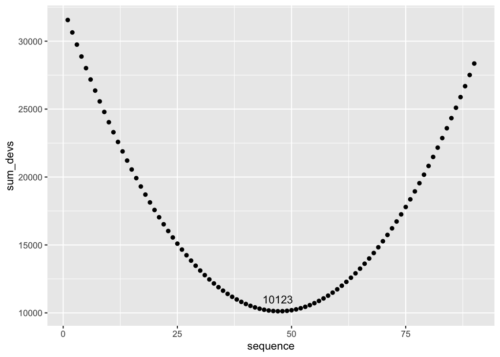

```r
sum_devs_data <- tibble(sum_devs)
sum_devs_data$sequence <- as.numeric(row.names(sum_devs_data))

ggplot(sum_devs_data) +
  geom_point(mapping = aes(x = sequence, y = sum_devs)) +
  geom_text(data = rbind(sum_devs_data[which.min(sum_devs_data$sum_devs), ]), mapping = aes(x = sequence, y = sum_devs), label = min(sum_devs_data$sum_devs), vjust = -1)
```

2. Write a custom R function for any one of the following descriptive statistics: median, mode, standard deviation, variance. Demonstrate that it produces the same value as the base R function given some set of numbers.

```r
std_dev <- function(scores) {
  return(sqrt(sum((scores - mean(scores)) ^ 2) / (length(scores) - 1)))
}

cat("\n Custom function \n")
```

```
##
##  Custom function
```

```r
std_dev(x)
```

```
## [1] 33.53622
```

```r
cat("\n R function \n")
```

```
##
##  R function
```

```r
sd(x)
```

```
## [1] 33.53622
```

3. Imagine the same instructor taught a morning, afternoon, and evening section of the same course. And, the average scores for each section on a midterm were 85% for the morning, 90% for the afternoon, and 93% for the evening sections. Create a data.frame representing these means for each section. Then, use ggplot2 to plot the means as bar graph. (hint you will need one vector for the class sections, and one vector for the means. Then you can combine them into a data.frame before plotting them)

```r
midterm_averages <- tibble(
  class_section = c("morning", "afternoon", "evening"),
  average_score = c(0.85, 0.90, 0.93)
)

midterm_averages
```

```
## # A tibble: 3 × 2
##   class_section average_score
##   <chr>                 <dbl>
## 1 morning                0.85
## 2 afternoon              0.9
## 3 evening                0.93
```

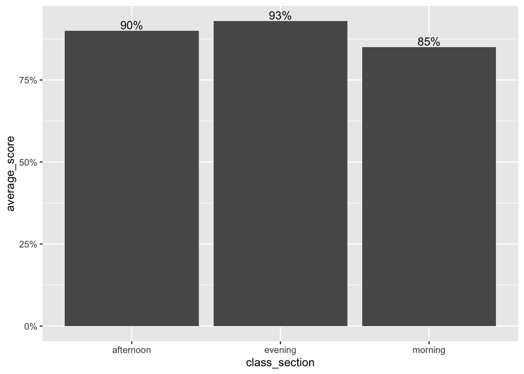

```r
ggplot(data = midterm_averages, mapping = aes(x = class_section, y = average_score)) +
  geom_col() +
  geom_text(mapping = aes(label = sprintf("%1.0f%%", average_score * 100)), vjust = -0.2) +
  scale_y_continuous(labels = scales::percent)
```

```r
midterm_averages2 <- tibble(
  class_section = c("morning", "afternoon", "evening", "morning", "afternoon", "evening"),
  instructor = c("instructor_1", "instructor_1", "instructor_1", "instructor_2", "instructor_2", "instructor_2"),
  average_score = c(0.85, 0.90, 0.93, 0.88, 0.76, 0.63)
)

midterm_averages2
```

```
## # A tibble: 6 × 3
##   class_section instructor   average_score
##   <chr>         <chr>                <dbl>
## 1 morning       instructor_1          0.85
## 2 afternoon     instructor_1          0.9
## 3 evening       instructor_1          0.93
## 4 morning       instructor_2          0.88
## 5 afternoon     instructor_2          0.76
## 6 evening       instructor_2          0.63
```

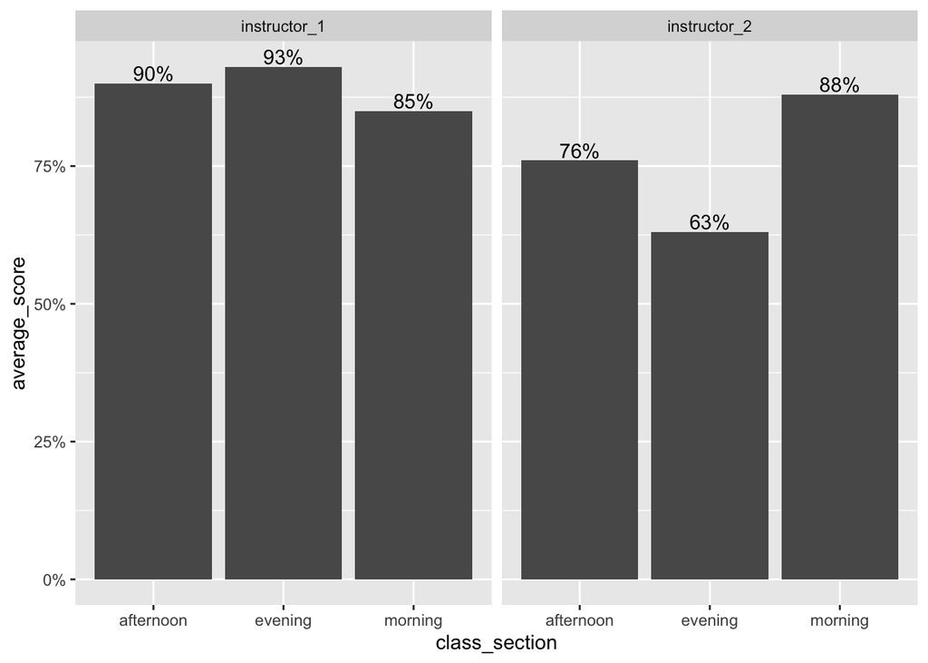

```r
ggplot(data = midterm_averages2, mapping = aes(x = class_section, y = average_score)) +
  geom_col() +
  facet_wrap(~ instructor) +
  geom_text(mapping = aes(label = sprintf("%1.0f%%", average_score * 100)), vjust = -0.2) +
  scale_y_continuous(labels = scales::percent)
```

5. Import the WHR2018.csv data file, containing measure from the World Happiness report from 2018. For the years 2010 to 2015, what was the mean “healthy life expectancy at birth” for each year (find the mean for each year across countries). Show your results in a table and in a graph using ggplot.

```r
df <- read.table("open_data/WHR2018.csv",
                 sep = ",",
                 header = TRUE)

df <- tibble(df)

df_grouped <- df %>%
  group_by(year) %>%
  summarise(
    mean_life_expectancy = mean(Healthy.life.expectancy.at.birth, na.rm = TRUE)
    ) %>%
  filter(year >= 2010, year <= 2015)

df_grouped
```

```
## # A tibble: 6 × 2
##    year mean_life_expectancy
##   <int>                <dbl>
## 1  2010                 62.5
## 2  2011                 61.7
## 3  2012                 62.7
## 4  2013                 62.7
## 5  2014                 62.7
## 6  2015                 63.0
```

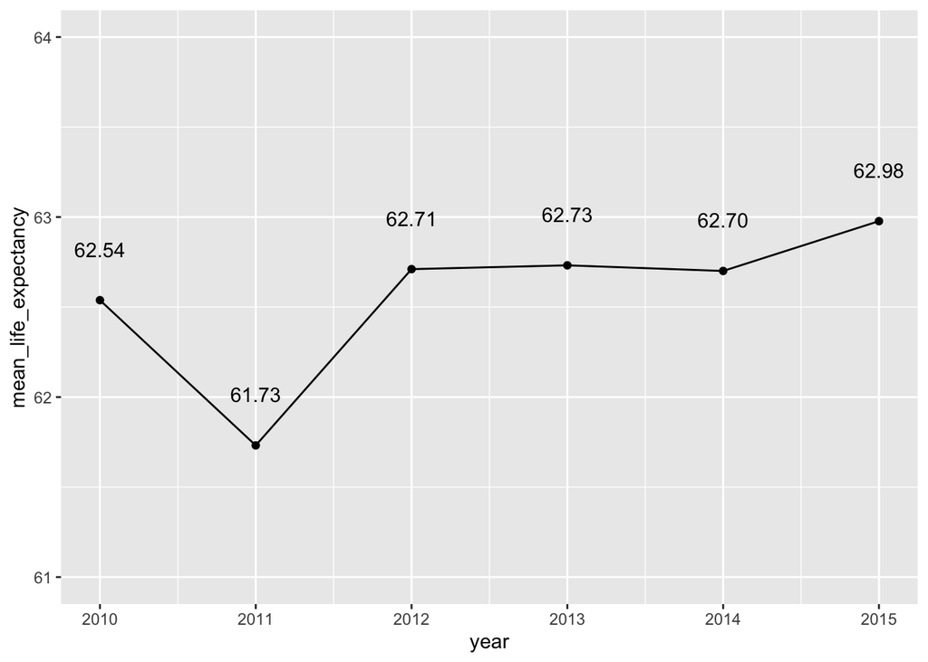

```r
ggplot(data = df_grouped, mapping = aes(x = year, y = mean_life_expectancy)) +
  geom_point() +
  geom_line() +
  geom_text(mapping = aes(label = sprintf("%1.2f", mean_life_expectancy)), vjust = -3) +
  ylim(61, 64)
```

6. Repeat the above, except in addition to calculating the mean for each year, also calculate the standard deviation for “healthy life expectancy at birth” for each year. Then, add error bars to your graph using the +1 and -1 standard deviations from the means for each year.

```r
df_grouped2 <- df %>%
  group_by(year) %>%
  summarise(
    mean_life_expectancy = mean(Healthy.life.expectancy.at.birth, na.rm = TRUE),
    std_dev_life_expectancy = sd(Healthy.life.expectancy.at.birth, na.rm = TRUE)
    ) %>%
  filter(year >= 2010, year <= 2015)

df_grouped2
```

```
## # A tibble: 6 × 3
##    year mean_life_expectancy std_dev_life_expectancy
##   <int>                <dbl>                   <dbl>
## 1  2010                 62.5                    7.87
## 2  2011                 61.7                    8.11
## 3  2012                 62.7                    7.34
## 4  2013                 62.7                    7.51
## 5  2014                 62.7                    7.70
## 6  2015                 63.0                    7.64
```

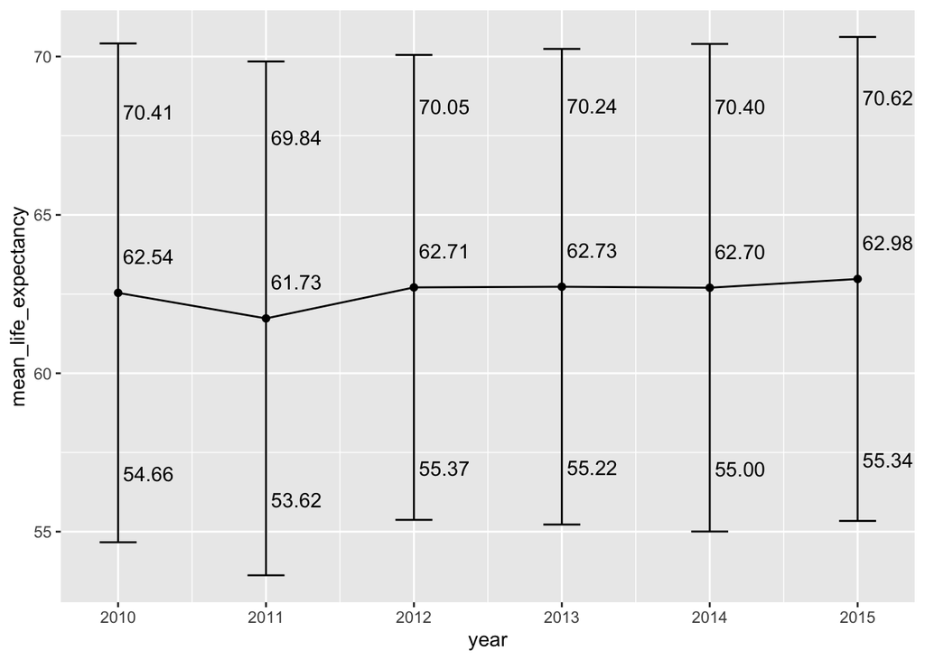

```r
ggplot(data = df_grouped2, mapping = aes(x = year, y = mean_life_expectancy)) +
  geom_point() +
  geom_line() +
  geom_errorbar(mapping = aes(ymin = mean_life_expectancy - std_dev_life_expectancy,
                              ymax = mean_life_expectancy + std_dev_life_expectancy),
                width = 0.25) +
  geom_text(mapping = aes(label = sprintf("%1.2f", mean_life_expectancy)), vjust = -2, hjust = -0.1) +
  geom_text(mapping = aes(label = sprintf("%1.2f", mean_life_expectancy - std_dev_life_expectancy)), vjust = 13, hjust = -0.1) +
  geom_text(mapping = aes(label = sprintf("%1.2f", mean_life_expectancy + std_dev_life_expectancy)), vjust = -12, hjust = -0.1)
```

I was able to solve the problems without assistance.